# hpgltools examples using pasilla

atb abelew@gmail.com

2019-12-09

# 1 Pasilla vignette: 20170820

# 2 Example hpgltool usage with a real data set (pasilla)

In this document, I am hoping to mostly copy/paste material from the tests/ tree and explain the various functionalities therein. It is my hope therefore to step from data loading all the way through ontology searching with appropriate visualizations at each stage.

# 3 Load Data

In test_01load_data.R I perform load some data into an expressionset and get ready to play with it.

```r
## I use sm to keep functions from printing too much (well, anything really)
tt <- sm(library(hpgltools))
tt <- sm(library(pasilla))
tt <- sm(data(pasillaGenes))
```

## 3.1 Gather annotation data

```r
## Try loading some annotation information for this species.
gene_info_lst <- sm(load_biomart_annotations(species="dmelanogaster"))
gene_info <- gene_info_lst[["annotation"]]
info_idx <- gene_info[["gene_biotype"]] == "protein_coding"
gene_info <- gene_info[info_idx, ]
rownames(gene_info) <- make.names(gene_info[["ensembl_gene_id"]], unique=TRUE)
head(gene_info)
```

```
##             ensembl_transcript_id ensembl_gene_id description   gene_biotype
## FBgn0260439           FBtr0005088     FBgn0260439          NA protein_coding
## FBgn0000056           FBtr0006151     FBgn0000056          NA protein_coding
## FBgn0031081           FBtr0070000     FBgn0031081          NA protein_coding
## FBgn0031085           FBtr0070002     FBgn0031085          NA protein_coding
## FBgn0062565           FBtr0070003     FBgn0062565          NA protein_coding
## FBgn0031089           FBtr0070006     FBgn0031089          NA protein_coding
##             cds_length chromosome_name strand start_position end_position
## FBgn0260439       1773              2L      +        8366038      8370090
## FBgn0000056        816              2L      +       14615552     14618902
## FBgn0031081       2358               X      +       19961297     19969323
## FBgn0031085        630               X      +       20051294     20052519
## FBgn0062565       1161               X      +       20094398     20095767
## FBgn0031089       1323               X      +       20148124     20155514
```

## 3.2 Load count tables

The pasilla data set provides count tables in a tab separated file, let us read them into an expressionset in the following block along with creating an experimental design. create_expt() will then merge the annotations, experimental design, and count tables into an expressionset.

```r
## This section is copy/pasted to all of these tests, that is dumb.
datafile <- system.file("extdata/pasilla_gene_counts.tsv", package="pasilla")
## Load the counts and drop super-low counts genes
counts <- read.table(datafile, header=TRUE, row.names=1)
counts <- counts[rowSums(counts) > ncol(counts),]
## Set up a quick design to be used by cbcbSEQ and hpgltools
design <- data.frame(row.names=colnames(counts),
    condition=c("untreated","untreated","untreated",
        "untreated","treated","treated","treated"),
    libType=c("single_end","single_end","paired_end",
        "paired_end","single_end","paired_end","paired_end"))
metadata <- design
colnames(metadata) <- c("condition", "batch")
metadata[["sampleid"]] <- rownames(metadata)

## Make sure it is still possible to create an expt
pasilla_expt <- sm(create_expt(count_dataframe=counts, metadata=metadata,
                               savefile="pasilla", gene_info=gene_info))
```

The rest of test_01load_data.R checks the various slots of the resulting expt to ensure that important stuff for future analyses are available, primarily: condition/batch, library sizes, annotations, counts.

# 4 Graph metrics

The next set of tests seek to ensure that the various plots used to visualize and understand trends in the data are maintained over time.

In this first block I will use a single function graph_metrics() to plot them all. And then follow up with the one at a time. Many functions in hpgltools are quite chatty with liberal usage of message(), as a result I will sm() this call to shut it up.

```r
pasilla_metrics <- sm(graph_metrics(pasilla_expt, ma=TRUE, qq=TRUE))
```

```r
summary(pasilla_metrics)
```

```
##                 Length Class        Mode
## boxplot          9     gg           list
## corheat          3     recordedplot list
## cvplot           9     gg           list
## density         10     gg           list
## density_table    5     data.table   list
## disheat          3     recordedplot list
## gene_heatmap     0     -none-       NULL
## legend           3     recordedplot list
## legend_colors    3     data.frame   list
## libsize          9     gg           list
## libsizes         4     data.table   list
## libsize_summary  7     data.table   list
## ma              21     -none-       list
## nonzero          9     gg           list
## nonzero_table    7     data.frame   list
## pc_loadplot      3     recordedplot list
## pc_summary       4     data.frame   list
## pc_propvar       6     -none-       numeric
## pc_plot          9     gg           list
## pc_table        14     data.frame   list
## qqlog            3     recordedplot list
## qqrat            3     recordedplot list
## smc              9     gg           list
## smd              9     gg           list
## topnplot         9     gg           list
## tsne_summary     4     data.frame   list
## tsne_propvar    20     -none-       numeric
## tsne_plot        9     gg           list
## tsne_table      10     data.frame   list
```

Now let us print the graphs

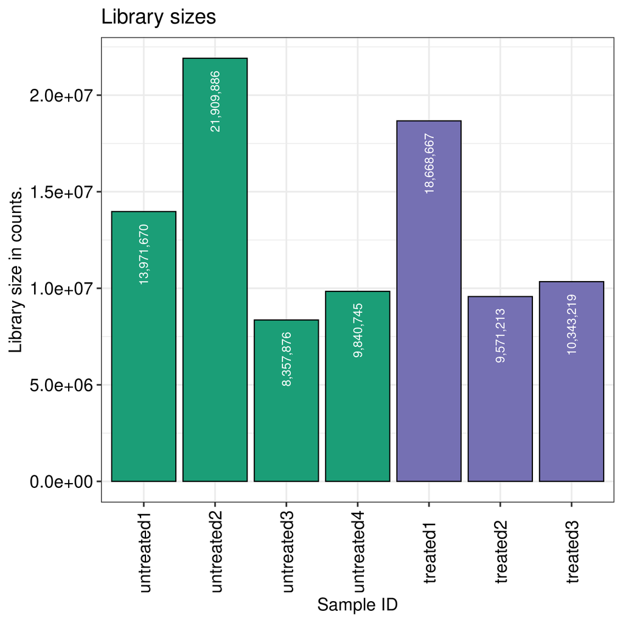

```r
pasilla_metrics$libsize
```

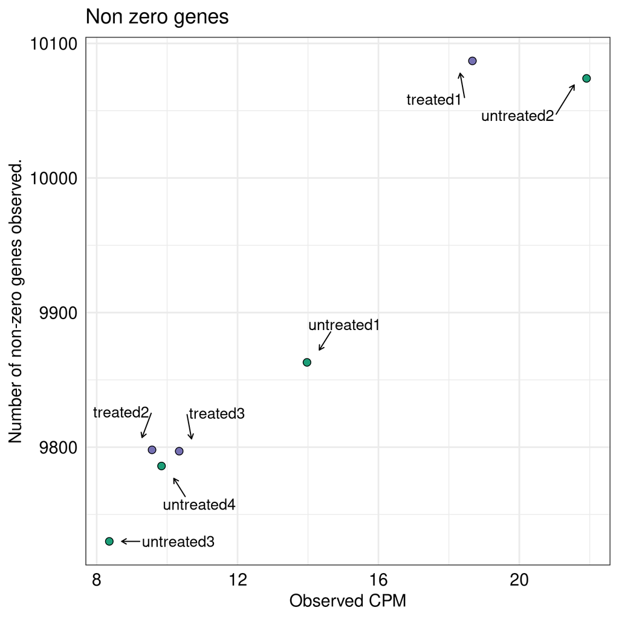

```r
## The library sizes range from 8-21 million reads, this might be a problem for
## some analyses.
pasilla_metrics$nonzero
```

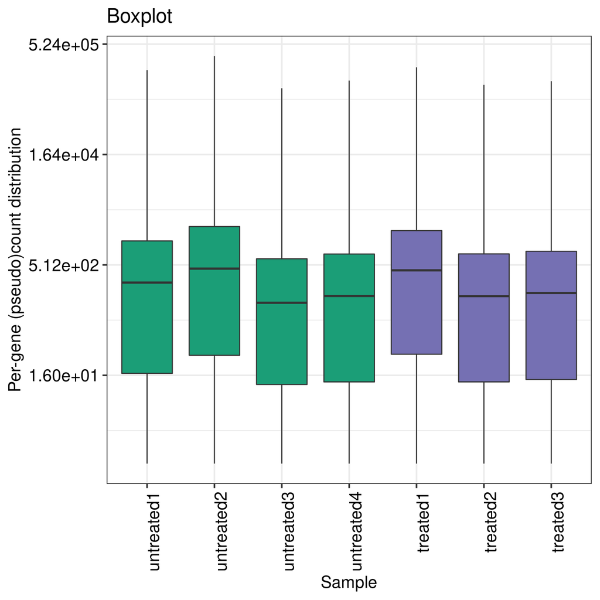

```r
## Ergo, the lower abundance libraries have more genes of counts == 0 (bottom
## left).
pasilla_metrics$boxplot
```

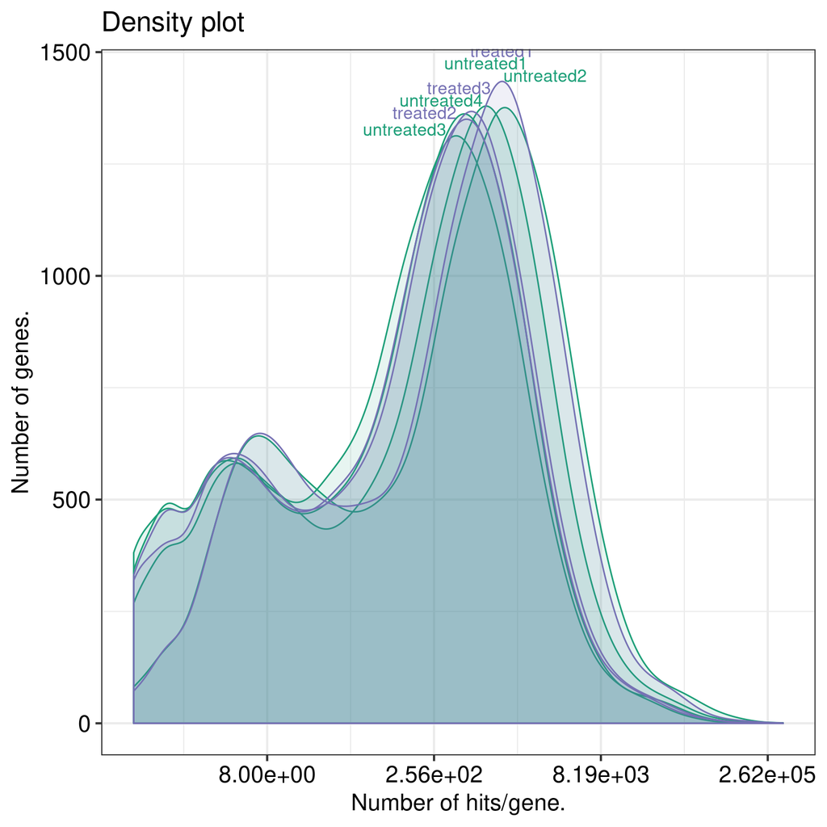

```r
## And a boxplot downshifts them (but not that much because it decided to put
## the data on the log scale).
pasilla_metrics$density
```

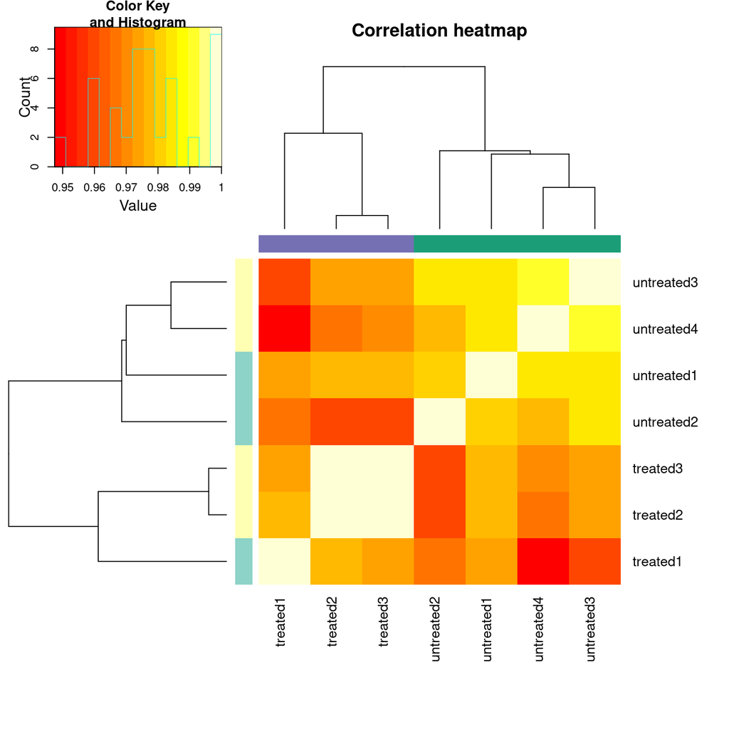

```r
## Similarly, one can see those samples are a bit lower with respect to density

## Unless the data is very well behaved, the rest of the plots are not likely to
## look good until the data is normalized, nonetheless, lets see
pasilla_metrics$corheat
```

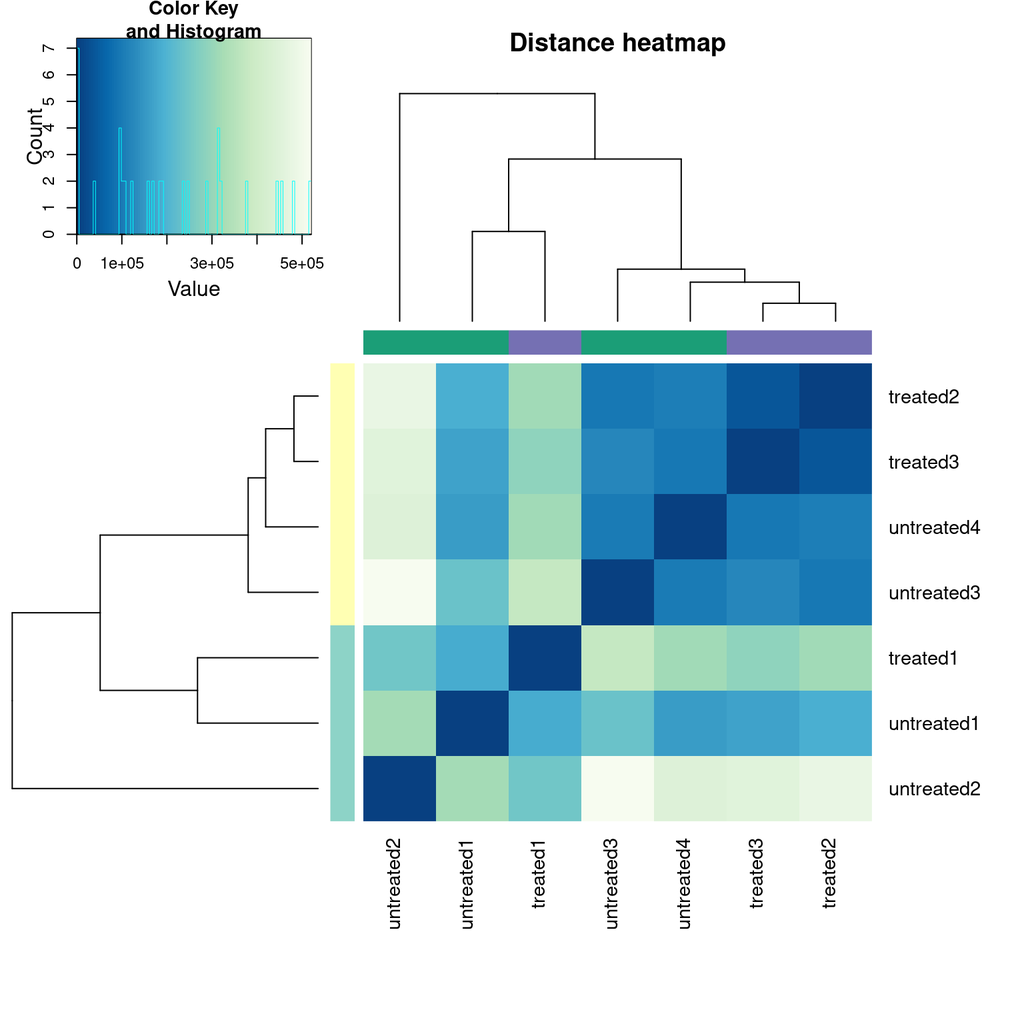

```r
pasilla_metrics$disheat
```

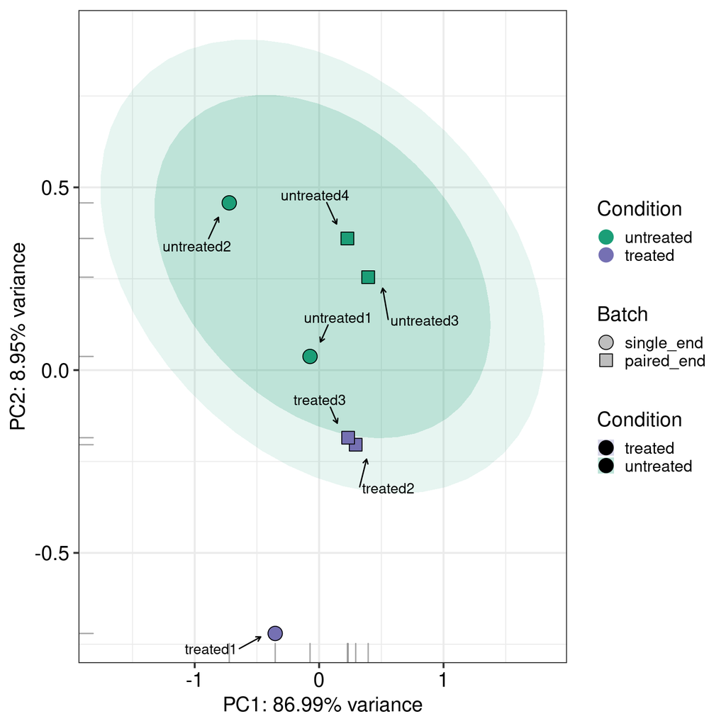

```r
pasilla_metrics$pc_plot
```

```r
## So the above 3 plots are pretty much the worst case scenario for this data.
```

# 5 Normalize and replot

The most common normalization suggested by Najib is a cpm(quantile(filter(data))). On top of that we often do log2() and/or a batch adjustment. default_norm() quietly does the first and may be supplemented with other arguments.

```r
norm <- default_norm(pasilla_expt, transform="log2")
norm_metrics <- graph_metrics(norm)
```

```
## Graphing number of non-zero genes with respect to CPM by library.
```

```
## Graphing library sizes.
```

```
## Graphing a boxplot.
```

```
## Graphing a correlation heatmap.
```

```
## Graphing a standard median correlation.
```

```
## Performing correlation.
```

```
## Graphing a distance heatmap.
```

```
## Graphing a standard median distance.
```

```
## Performing distance.
```

```
## Graphing a PCA plot.
```

```
## Graphing a T-SNE plot.
```

```
## Plotting a density plot.
```

```
## Plotting a CV plot.
```

```
## Naively calculating coefficient of variation/dispersion with respect to condition.
```

```
## Finished calculating dispersion estimates.
```

```
## Plotting the representation of the top-n genes.
```

```
## Plotting the expression of the top-n PC loaded genes.
```

```
## Printing a color to condition legend.
```

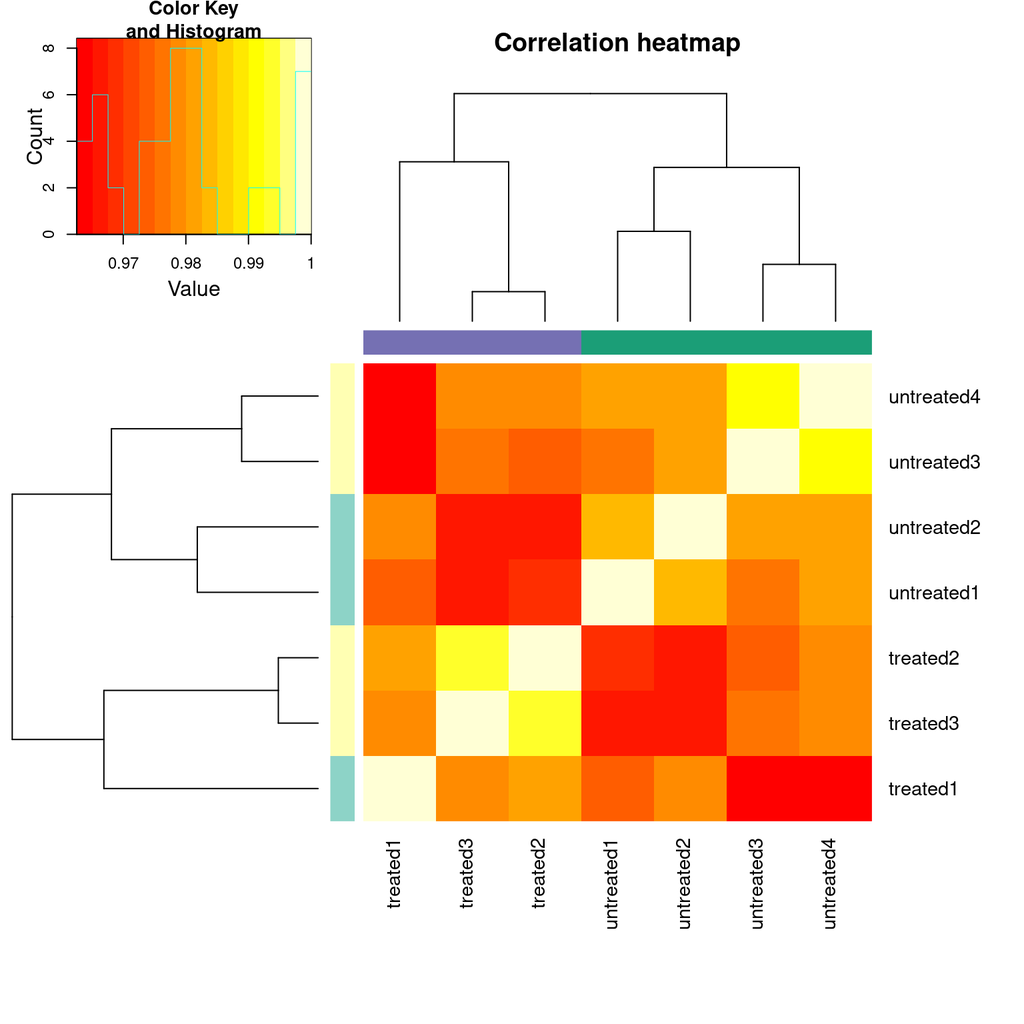

```r
norm_metrics$corheat
```

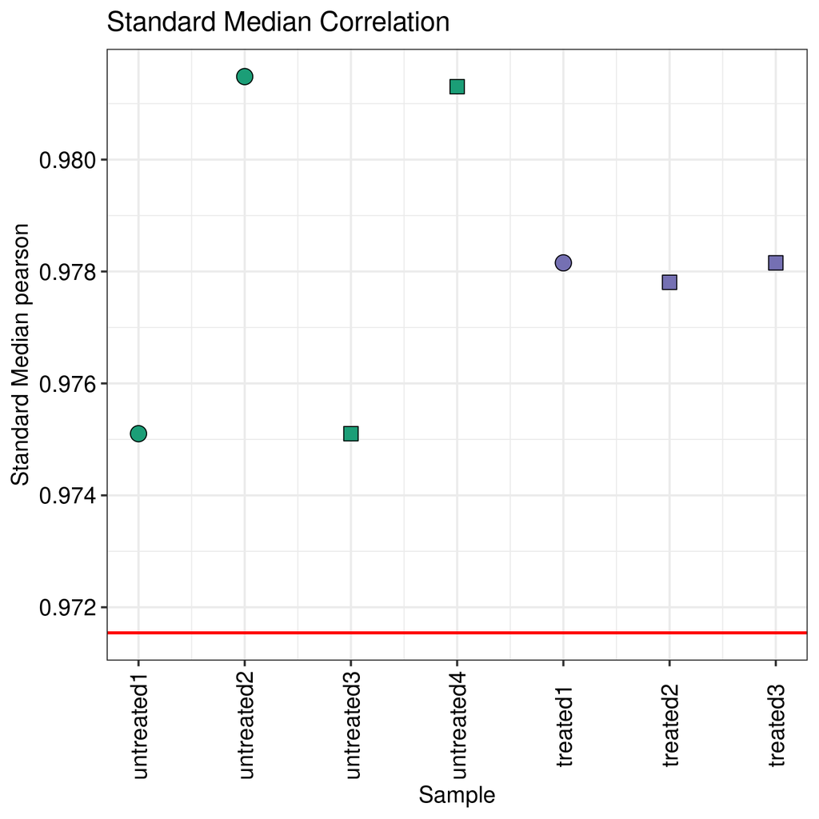

```r
norm_metrics$smc
```

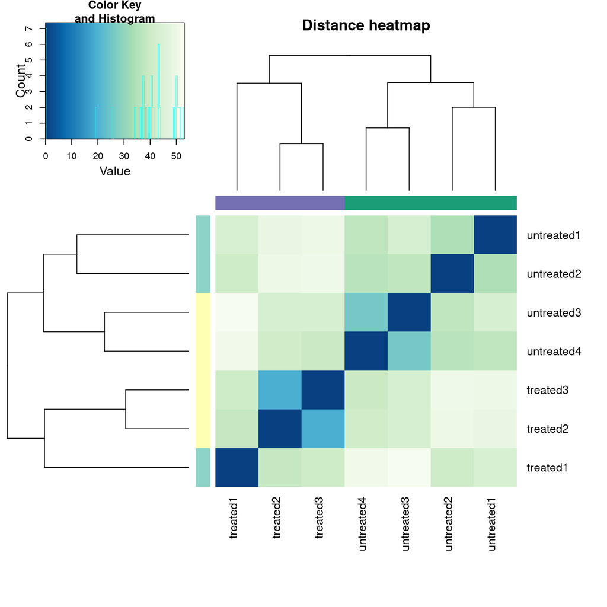

```r
norm_metrics$disheat
```

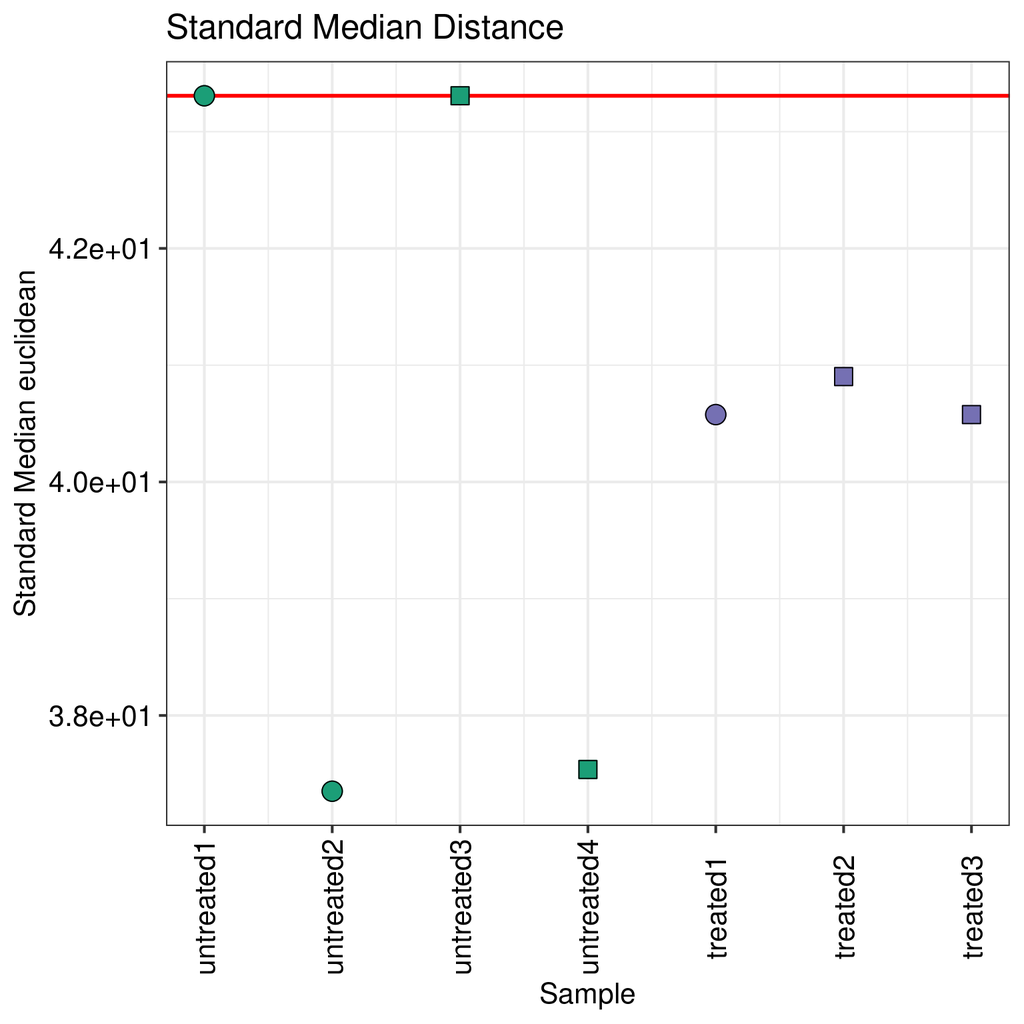

```r
norm_metrics$smd
```

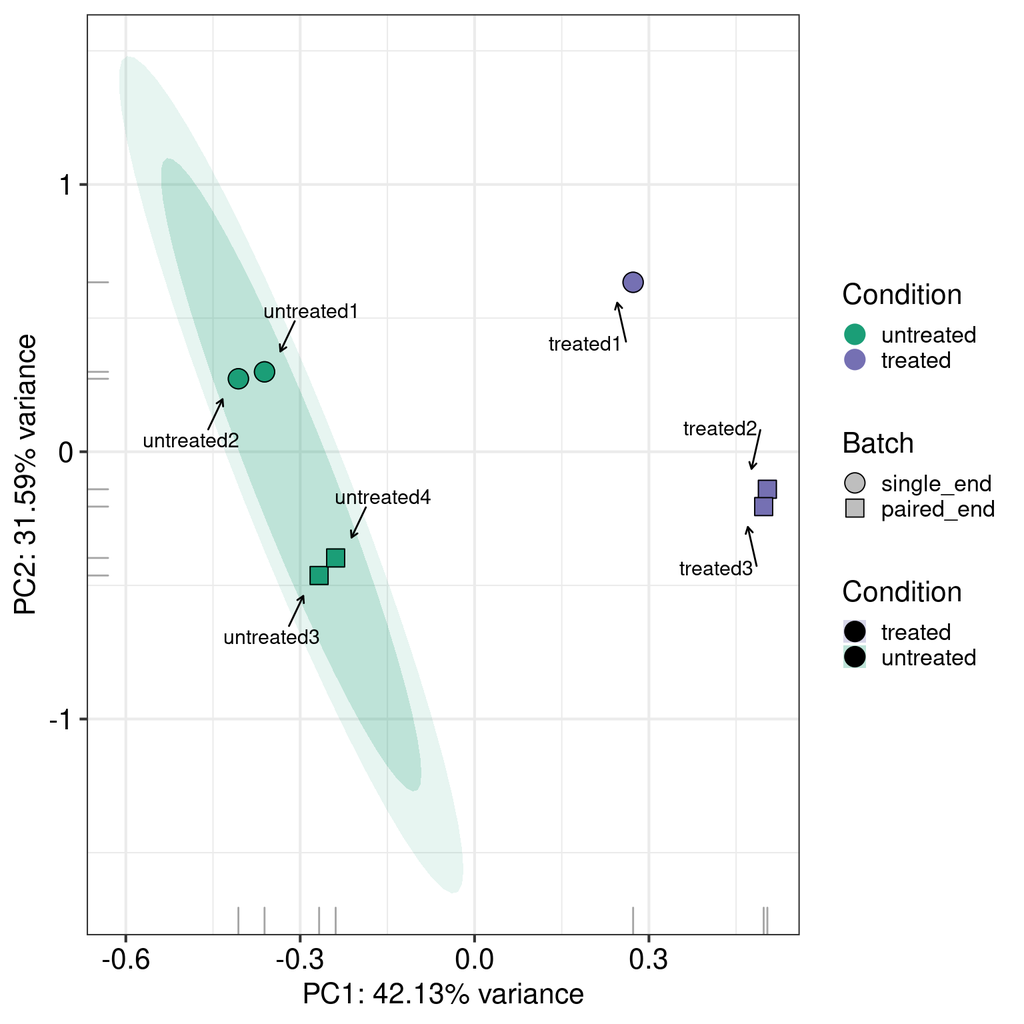

```r
## some samples look a little troublesome here.
norm_metrics$pc_plot
```

# 6 Try a pairwise comparison

```r
pasilla_pairwise <- sm(all_pairwise(pasilla_expt))
pasilla_tables <- sm(combine_de_tables(
  pasilla_pairwise,
  excel="pasilla_tables.xlsx"))
```

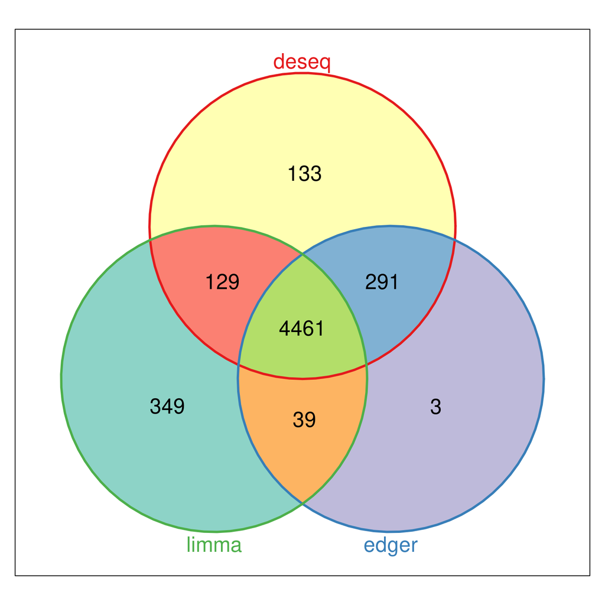

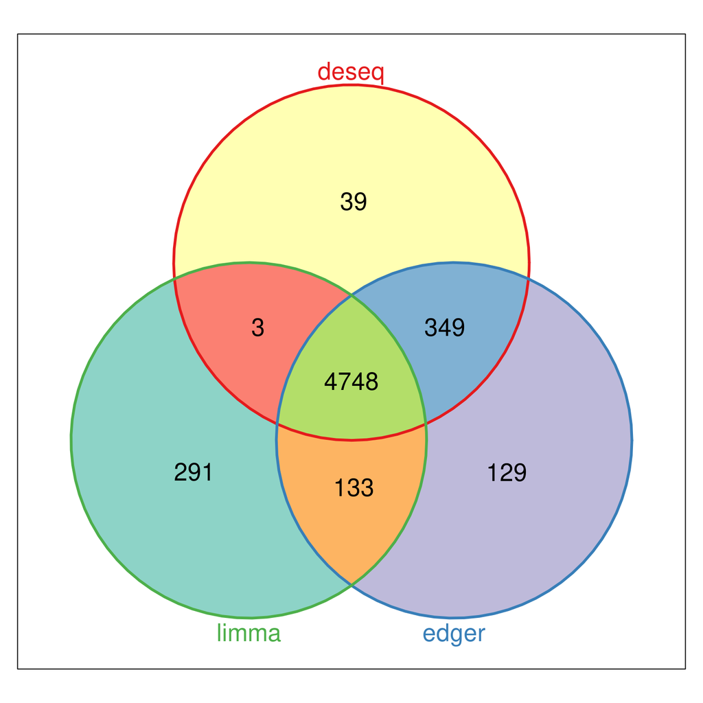

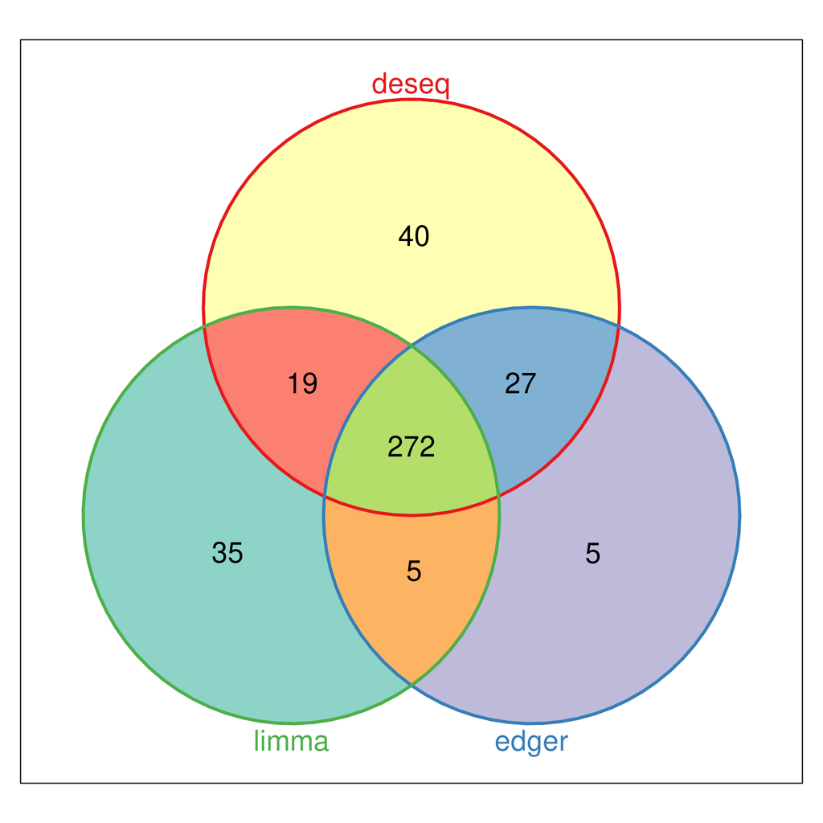

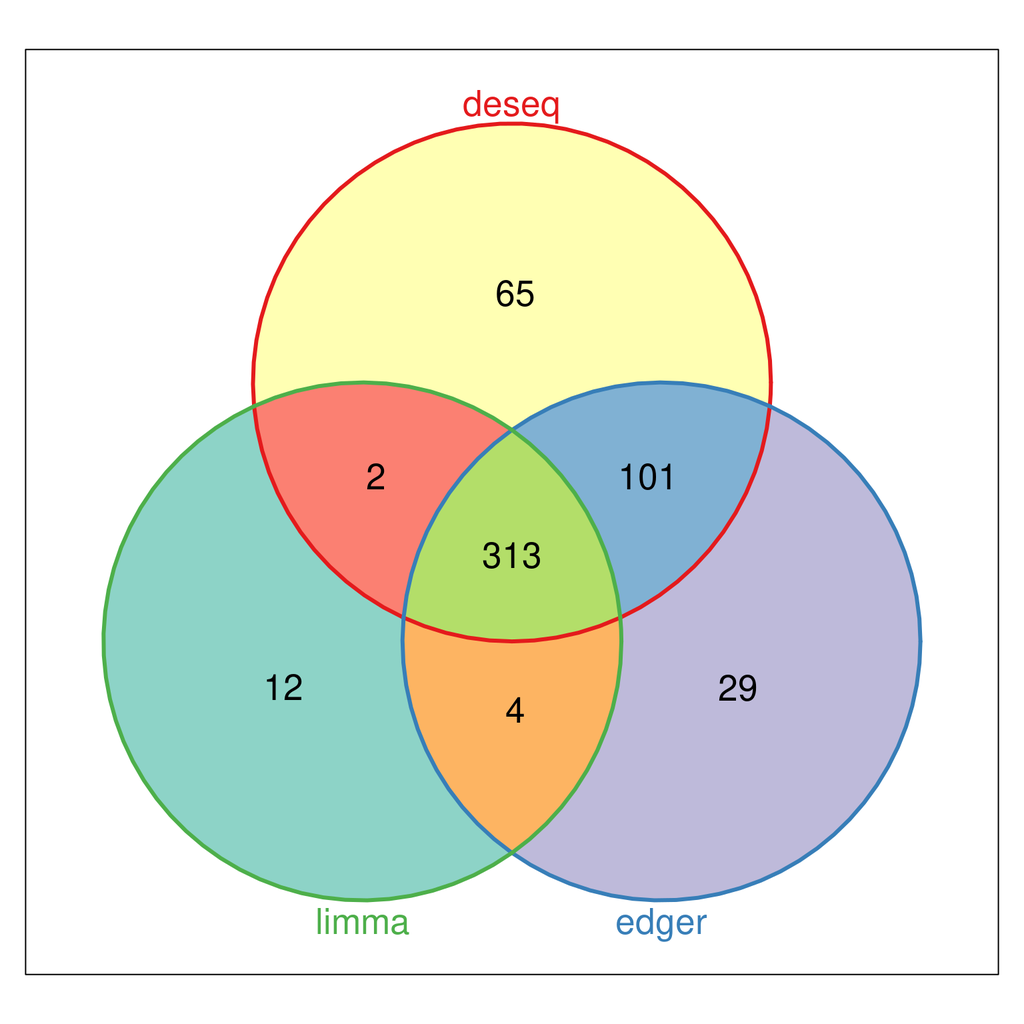

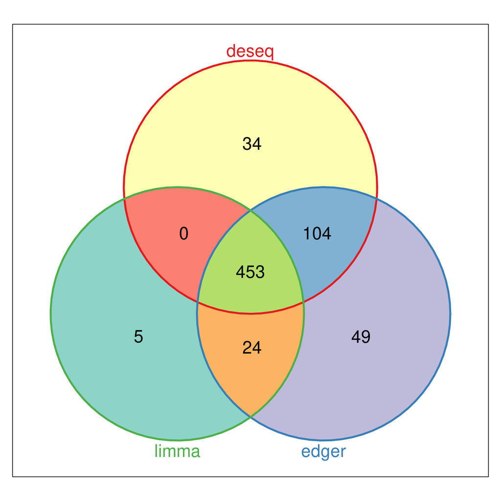

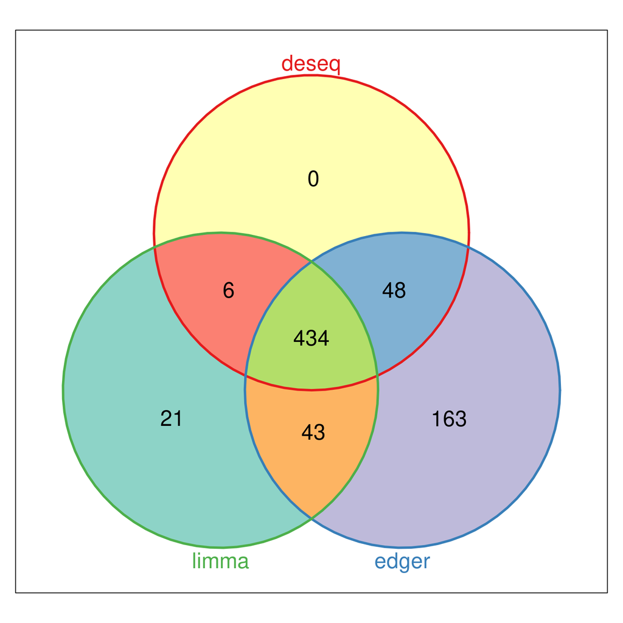

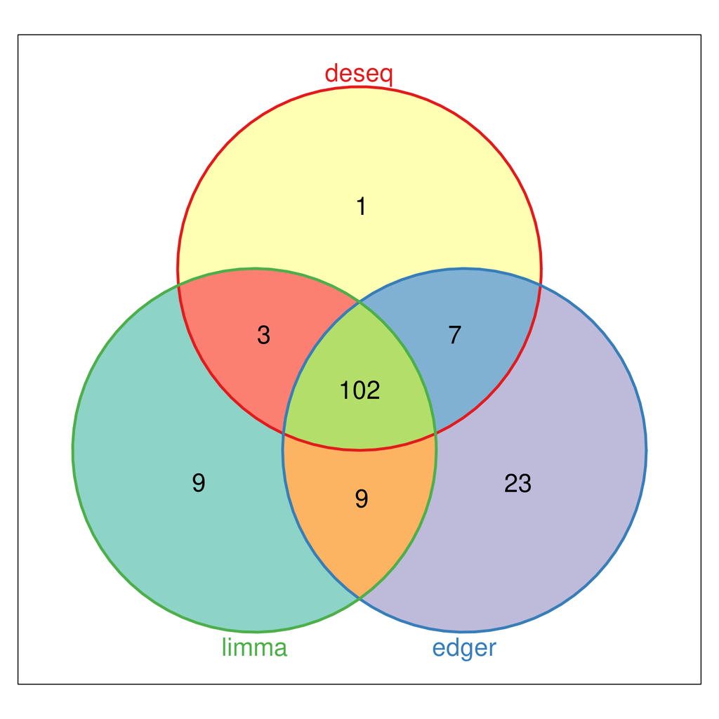

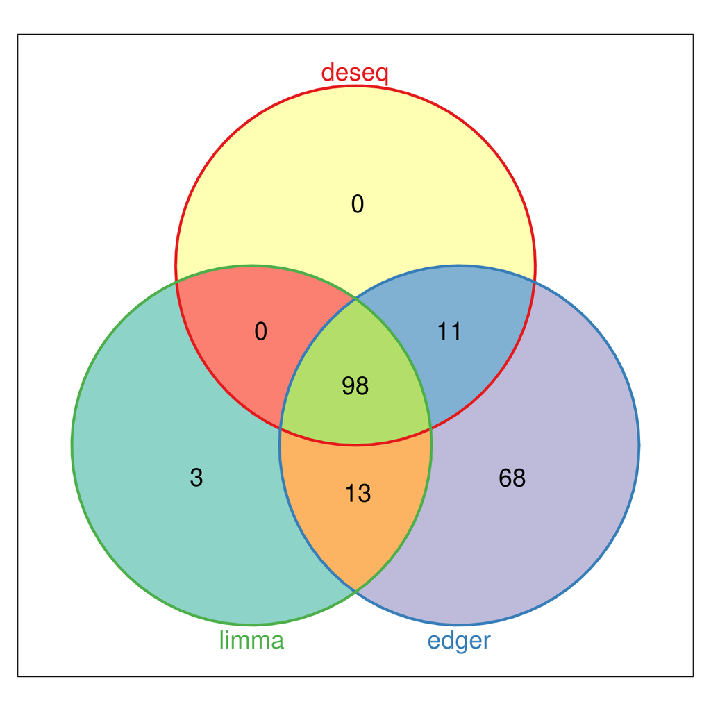

```r
pasilla_sig <- sm(extract_significant_genes(
  pasilla_tables,
  excel="pasilla_sig.xlsx"))
pasilla_ab <- sm(extract_abundant_genes(
  pasilla_pairwise,
  excel="pasilla_abundant.xlsx"))
pasilla_tables$deseq_ma_plots[[1]]$plot
```

[output not shown]

[session information not shown]

**R version 3.6.1 (2019-07-05)**

**Platform:** x86_64-pc-linux-gnu (64-bit)

**locale:** *LC_CTYPE=en_US.UTF-8*, *LC_NUMERIC=C*, *LC_TIME=en_US.UTF-8*, *LC_COLLATE=en_US.UTF-8*, *LC_MONETARY=en_US.UTF-8*, *LC_MESSAGES=en_US.UTF-8*, *LC_PAPER=en_US.UTF-8*, *LC_NAME=C*, *LC_ADDRESS=C*, *LC_TELEPHONE=C*, *LC_MEASUREMENT=en_US.UTF-8* and *LC_IDENTIFICATION=C*

**attached base packages:** *stats4*, *parallel*, *stats*, *graphics*, *grDevices*, *utils*, *datasets*, *methods* and *base*

**other attached packages:** *pasilla(v.1.14.0)*, *GO.db(v.3.10.0)*, *AnnotationDbi(v.1.48.0)*, *GOstats(v.2.52.0)*, *edgeR(v.3.28.0)*, *variancePartition(v.1.16.0)*, *fission(v.1.6.0)*, *ruv(v.0.9.7.1)*, *SummarizedExperiment(v.1.16.0)*, *DelayedArray(v.0.12.0)*, *BiocParallel(v.1.20.0)*, *matrixStats(v.0.55.0)*, *GenomicRanges(v.1.38.0)*, *GenomeInfoDb(v.1.22.0)*, *IRanges(v.2.20.0)*, *S4Vectors(v.0.24.0)*, *hpgltools(v.1.0)*, *Biobase(v.2.46.0)* and *BiocGenerics(v.0.32.0)*

```r
message(paste0("This is hpgltools commit: ", get_git_commit()))
```

```
## If you wish to reproduce this exact build of hpgltools, invoke the following:
```

```
## > git clone http://github.com/abelew/hpgltools.git
```

```
## > git reset ca7dfe3c77056f495da05ef0c95b6208370a23f1commit!
```

```
## This is hpgltools commit: Sat Nov 23 19:41:15 2019 -0500: ca7dfe3c77056f495da05ef0c95b6208370a23f1This is hpgltools commit: Sat Nov 23 19:41:15 2019 -0500: commit!
```